# Optimal Treatment Analysis

## Outcome Variable

**Outcome Variable:** whz

## Predictor Variables

**Intervention Variable:** exclfeed36

**Adjustment Set:**

- arm
- sex
- brthmon
- W_mage
- meducyrs
- feducyrs
- hhwealth_quart
- hfoodsec
- W_mhtcm
- W_mwtkg
- W_mbmi
- vagbrth
- W_gagebrth
- W_birthwt
- W_birthlen
- W_nrooms
- W_nchldlt5
- month
- W_parity
- impfloor
- impsan
- safeh20
- delta_W_mage
- delta_meducyrs
- delta_feducyrs
- delta_hhwealth_quart
- delta_hfoodsec
- delta_W_mhtcm
- delta_W_mwtkg
- delta_W_mbmi
- delta_vagbrth
- delta_W_gagebrth
- delta_W_birthwt
- delta_W_birthlen
- delta_W_nrooms
- delta_W_nchldlt5
- delta_month
- delta_W_parity
- delta_impfloor
- delta_impsan
- delta_safeh20

## Stratifying Variables

The analysis was stratified on these variable(s):

- agecat
- studyid
- country

## Data Summary

| agecat | studyid | country | exclfeed36 | n_cell | n |
| --- | --- | --- | --- | --- | --- |
| Birth | ki0047075b-MAL-ED | BANGLADESH | 1 | 31 | 208 |
| Birth | ki0047075b-MAL-ED | BANGLADESH | 0 | 177 | 208 |
| Birth | ki0047075b-MAL-ED | BRAZIL | 1 | 4 | 62 |
| Birth | ki0047075b-MAL-ED | BRAZIL | 0 | 58 | 62 |
| Birth | ki0047075b-MAL-ED | INDIA | 1 | 1 | 40 |
| Birth | ki0047075b-MAL-ED | INDIA | 0 | 39 | 40 |
| Birth | ki0047075b-MAL-ED | NEPAL | 1 | 0 | 25 |
| Birth | ki0047075b-MAL-ED | NEPAL | 0 | 25 | 25 |
| Birth | ki0047075b-MAL-ED | PERU | 1 | 5 | 218 |
| Birth | ki0047075b-MAL-ED | PERU | 0 | 213 | 218 |
| Birth | ki0047075b-MAL-ED | SOUTH AFRICA | 1 | 1 | 104 |
| Birth | ki0047075b-MAL-ED | SOUTH AFRICA | 0 | 103 | 104 |
| Birth | ki0047075b-MAL-ED | TANZANIA, UNITED REPUBLIC OF | 1 | 0 | 111 |
| Birth | ki0047075b-MAL-ED | TANZANIA, UNITED REPUBLIC OF | 0 | 111 | 111 |
| Birth | ki1000108-CMC-V-BCS-2002 | INDIA | 1 | 3 | 3 |
| Birth | ki1000108-CMC-V-BCS-2002 | INDIA | 0 | 0 | 3 |
| Birth | ki1000108-IRC | INDIA | 1 | 0 | 3 |
| Birth | ki1000108-IRC | INDIA | 0 | 3 | 3 |
| Birth | ki1000109-EE | PAKISTAN | 1 | 2 | 6 |
| Birth | ki1000109-EE | PAKISTAN | 0 | 4 | 6 |
| Birth | ki1017093b-PROVIDE | BANGLADESH | 1 | 115 | 483 |
| Birth | ki1017093b-PROVIDE | BANGLADESH | 0 | 368 | 483 |
| Birth | ki1101329-Keneba | GAMBIA | 1 | 343 | 1192 |
| Birth | ki1101329-Keneba | GAMBIA | 0 | 849 | 1192 |
| Birth | ki1113344-GMS-Nepal | NEPAL | 1 | 396 | 491 |
| Birth | ki1113344-GMS-Nepal | NEPAL | 0 | 95 | 491 |
| Birth | kiGH5241-JiVitA-3 | BANGLADESH | 1 | 8189 | 10491 |
| Birth | kiGH5241-JiVitA-3 | BANGLADESH | 0 | 2302 | 10491 |
| Birth | kiGH5241-JiVitA-4 | BANGLADESH | 1 | 1711 | 2128 |
| Birth | kiGH5241-JiVitA-4 | BANGLADESH | 0 | 417 | 2128 |

[output cut: 66 more lines]

The following strata were considered:

- agecat: 24 months, studyid: ki0047075b-MAL-ED, country: BANGLADESH
- agecat: 24 months, studyid: ki0047075b-MAL-ED, country: BRAZIL
- agecat: 24 months, studyid: ki0047075b-MAL-ED, country: INDIA
- agecat: 24 months, studyid: ki0047075b-MAL-ED, country: NEPAL
- agecat: 24 months, studyid: ki0047075b-MAL-ED, country: PERU
- agecat: 24 months, studyid: ki0047075b-MAL-ED, country: SOUTH AFRICA
- agecat: 24 months, studyid: ki0047075b-MAL-ED, country: TANZANIA, UNITED REPUBLIC OF
- agecat: 24 months, studyid: ki1000108-CMC-V-BCS-2002, country: INDIA
- agecat: 24 months, studyid: ki1000108-IRC, country: INDIA
- agecat: 24 months, studyid: ki1000109-EE, country: PAKISTAN
- agecat: 24 months, studyid: ki1017093b-PROVIDE, country: BANGLADESH
- agecat: 24 months, studyid: ki1101329-Keneba, country: GAMBIA
- agecat: 24 months, studyid: ki1113344-GMS-Nepal, country: NEPAL
- agecat: 24 months, studyid: ki1148112-LCNI-5, country: MALAWI
- agecat: 24 months, studyid: kiGH5241-JiVitA-3, country: BANGLADESH
- agecat: 24 months, studyid: kiGH5241-JiVitA-4, country: BANGLADESH
- agecat: 6 months, studyid: ki0047075b-MAL-ED, country: BANGLADESH
- agecat: 6 months, studyid: ki0047075b-MAL-ED, country: BRAZIL
- agecat: 6 months, studyid: ki0047075b-MAL-ED, country: INDIA
- agecat: 6 months, studyid: ki0047075b-MAL-ED, country: NEPAL
- agecat: 6 months, studyid: ki0047075b-MAL-ED, country: PERU
- agecat: 6 months, studyid: ki0047075b-MAL-ED, country: SOUTH AFRICA
- agecat: 6 months, studyid: ki0047075b-MAL-ED, country: TANZANIA, UNITED REPUBLIC OF
- agecat: 6 months, studyid: ki1000108-CMC-V-BCS-2002, country: INDIA
- agecat: 6 months, studyid: ki1000108-IRC, country: INDIA
- agecat: 6 months, studyid: ki1000109-EE, country: PAKISTAN
- agecat: 6 months, studyid: ki1000304b-SAS-FoodSuppl, country: INDIA
- agecat: 6 months, studyid: ki1017093b-PROVIDE, country: BANGLADESH
- agecat: 6 months, studyid: ki1101329-Keneba, country: GAMBIA
- agecat: 6 months, studyid: ki1113344-GMS-Nepal, country: NEPAL
- agecat: 6 months, studyid: ki1148112-LCNI-5, country: MALAWI
- agecat: 6 months, studyid: kiGH5241-JiVitA-3, country: BANGLADESH
- agecat: 6 months, studyid: kiGH5241-JiVitA-4, country: BANGLADESH
- agecat: Birth, studyid: ki0047075b-MAL-ED, country: BANGLADESH
- agecat: Birth, studyid: ki0047075b-MAL-ED, country: BRAZIL
- agecat: Birth, studyid: ki0047075b-MAL-ED, country: INDIA
- agecat: Birth, studyid: ki0047075b-MAL-ED, country: NEPAL
- agecat: Birth, studyid: ki0047075b-MAL-ED, country: PERU
- agecat: Birth, studyid: ki0047075b-MAL-ED, country: SOUTH AFRICA
- agecat: Birth, studyid: ki0047075b-MAL-ED, country: TANZANIA, UNITED REPUBLIC OF
- agecat: Birth, studyid: ki1000108-CMC-V-BCS-2002, country: INDIA
- agecat: Birth, studyid: ki1000108-IRC, country: INDIA
- agecat: Birth, studyid: ki1000109-EE, country: PAKISTAN
- agecat: Birth, studyid: ki1017093b-PROVIDE, country: BANGLADESH
- agecat: Birth, studyid: ki1101329-Keneba, country: GAMBIA
- agecat: Birth, studyid: ki1113344-GMS-Nepal, country: NEPAL
- agecat: Birth, studyid: kiGH5241-JiVitA-3, country: BANGLADESH
- agecat: Birth, studyid: kiGH5241-JiVitA-4, country: BANGLADESH

### Dropped Strata

Some strata were dropped due to rare outcomes:

- agecat: Birth, studyid: ki0047075b-MAL-ED, country: BRAZIL
- agecat: Birth, studyid: ki0047075b-MAL-ED, country: INDIA
- agecat: Birth, studyid: ki0047075b-MAL-ED, country: NEPAL
- agecat: Birth, studyid: ki0047075b-MAL-ED, country: SOUTH AFRICA
- agecat: Birth, studyid: ki0047075b-MAL-ED, country: TANZANIA, UNITED REPUBLIC OF
- agecat: Birth, studyid: ki1000108-CMC-V-BCS-2002, country: INDIA
- agecat: Birth, studyid: ki1000108-IRC, country: INDIA
- agecat: Birth, studyid: ki1000109-EE, country: PAKISTAN
- agecat: 6 months, studyid: ki0047075b-MAL-ED, country: NEPAL
- agecat: 6 months, studyid: ki0047075b-MAL-ED, country: SOUTH AFRICA
- agecat: 6 months, studyid: ki0047075b-MAL-ED, country: TANZANIA, UNITED REPUBLIC OF
- agecat: 6 months, studyid: ki1000108-CMC-V-BCS-2002, country: INDIA
- agecat: 6 months, studyid: ki1000108-IRC, country: INDIA
- agecat: 6 months, studyid: ki1000109-EE, country: PAKISTAN
- agecat: 6 months, studyid: ki1000304b-SAS-FoodSuppl, country: INDIA
- agecat: 24 months, studyid: ki0047075b-MAL-ED, country: NEPAL
- agecat: 24 months, studyid: ki0047075b-MAL-ED, country: PERU
- agecat: 24 months, studyid: ki0047075b-MAL-ED, country: SOUTH AFRICA
- agecat: 24 months, studyid: ki0047075b-MAL-ED, country: TANZANIA, UNITED REPUBLIC OF
- agecat: 24 months, studyid: ki1000108-CMC-V-BCS-2002, country: INDIA
- agecat: 24 months, studyid: ki1000108-IRC, country: INDIA
- agecat: 24 months, studyid: ki1000109-EE, country: PAKISTAN

## Methods Detail

We’re interested in the causal parameters $E[Y_a]$ for all values of $a \in \mathcal{A}$. These parameters represent the mean outcome if, possibly contrary to fact, we intervened to set all units to have $A=a$. Under the randomization and positivity assumptions, these are identified by the statistical parameters $\psi_a=E_W[E_{Y|A,W}(Y|A=a,W)]$. In addition, we’re interested in the mean of $Y$, $E[Y]$ under no intervention (the observed mean). We will estimate these parameters by using SuperLearner to fit the relevant likelihood factors – $E_{Y|A,W}(Y|A=a,W)$ and $p(A=a|W)$, and then updating our likelihood fit using a joint TMLE.

For unadjusted analyses ($W=\{\}$), initial likelihoods were estimated using Lrnr_glm to estimate the simple $E(Y|A)$ and Lrnr_mean to estimate $p(A)$. For adjusted analyses, a small library containing Lrnr_glmnet, Lrnr_xgboost, and Lrnr_mean was used.

Having estimated these parameters, we will then use the delta method to estimate relative risks and attributable risks relative to a prespecified baseline level of $A$.

# Results Detail

## Results Plots

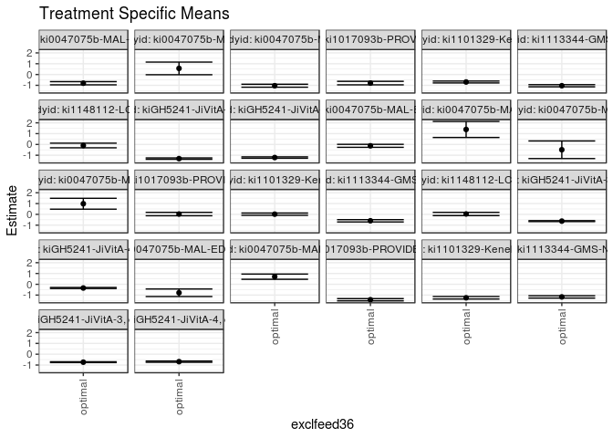

## Results Table

### Parameter: TSM

| agecat | studyid | country | intervention_level | baseline_level | estimate | ci_lower | ci_upper |
| --- | --- | --- | --- | --- | --- | --- | --- |
| Birth | ki0047075b-MAL-ED | BANGLADESH | optimal | observed | -0.7837772 | -1.1333765 | -0.4341780 |
| Birth | ki0047075b-MAL-ED | PERU | optimal | observed | 0.7049544 | 0.4636335 | 0.9462752 |
| Birth | ki1017093b-PROVIDE | BANGLADESH | optimal | observed | -1.4291216 | -1.5305158 | -1.3277274 |
| Birth | ki1101329-Keneba | GAMBIA | optimal | observed | -1.2496354 | -1.3653878 | -1.1338830 |
| Birth | ki1113344-GMS-Nepal | NEPAL | optimal | observed | -1.1677936 | -1.2761063 | -1.0594810 |
| Birth | kiGH5241-JiVitA-3 | BANGLADESH | optimal | observed | -0.7371826 | -0.7762132 | -0.6981519 |
| Birth | kiGH5241-JiVitA-4 | BANGLADESH | optimal | observed | -0.6889553 | -0.7450603 | -0.6328503 |
| 6 months | ki0047075b-MAL-ED | BANGLADESH | optimal | observed | -0.1284404 | -0.2662981 | 0.0094172 |
| 6 months | ki0047075b-MAL-ED | BRAZIL | optimal | observed | 1.3856973 | 0.6436497 | 2.1277450 |
| 6 months | ki0047075b-MAL-ED | INDIA | optimal | observed | -0.4912558 | -1.3060932 | 0.3235815 |
| 6 months | ki0047075b-MAL-ED | PERU | optimal | observed | 0.9831539 | 0.4798024 | 1.4865055 |
| 6 months | ki1017093b-PROVIDE | BANGLADESH | optimal | observed | 0.0309703 | -0.1267837 | 0.1887244 |
| 6 months | ki1101329-Keneba | GAMBIA | optimal | observed | 0.0169761 | -0.0879193 | 0.1218715 |
| 6 months | ki1113344-GMS-Nepal | NEPAL | optimal | observed | -0.5950374 | -0.7014121 | -0.4886626 |
| 6 months | ki1148112-LCNI-5 | MALAWI | optimal | observed | 0.0371578 | -0.1144667 | 0.1887823 |
| 6 months | kiGH5241-JiVitA-3 | BANGLADESH | optimal | observed | -0.6253907 | -0.6671244 | -0.5836570 |
| 6 months | kiGH5241-JiVitA-4 | BANGLADESH | optimal | observed | -0.3433540 | -0.3895004 | -0.2972076 |
| 24 months | ki0047075b-MAL-ED | BANGLADESH | optimal | observed | -0.8063964 | -0.9536226 | -0.6591701 |
| 24 months | ki0047075b-MAL-ED | BRAZIL | optimal | observed | 0.5659085 | -0.0202511 | 1.1520680 |
| 24 months | ki0047075b-MAL-ED | INDIA | optimal | observed | -1.0385518 | -1.1754231 | -0.9016805 |
| 24 months | ki1017093b-PROVIDE | BANGLADESH | optimal | observed | -0.7941374 | -0.9560072 | -0.6322676 |
| 24 months | ki1101329-Keneba | GAMBIA | optimal | observed | -0.6936496 | -0.7826399 | -0.6046594 |
| 24 months | ki1113344-GMS-Nepal | NEPAL | optimal | observed | -1.0384610 | -1.1393918 | -0.9375301 |
| 24 months | ki1148112-LCNI-5 | MALAWI | optimal | observed | -0.0982166 | -0.3120434 | 0.1156102 |
| 24 months | kiGH5241-JiVitA-3 | BANGLADESH | optimal | observed | -1.3106048 | -1.3735718 | -1.2476378 |
| 24 months | kiGH5241-JiVitA-4 | BANGLADESH | optimal | observed | -1.2130530 | -1.2760126 | -1.1500934 |

### Parameter: E(Y)

| agecat | studyid | country | intervention_level | baseline_level | estimate | ci_lower | ci_upper |
| --- | --- | --- | --- | --- | --- | --- | --- |
| Birth | ki0047075b-MAL-ED | BANGLADESH | observed | observed | -0.9474038 | -1.0929246 | -0.8018831 |
| Birth | ki0047075b-MAL-ED | PERU | observed | observed | -0.0458257 | -0.1696487 | 0.0779973 |
| Birth | ki1017093b-PROVIDE | BANGLADESH | observed | observed | -1.2966874 | -1.3774293 | -1.2159454 |
| Birth | ki1101329-Keneba | GAMBIA | observed | observed | -1.2752643 | -1.3442810 | -1.2062476 |
| Birth | ki1113344-GMS-Nepal | NEPAL | observed | observed | -1.1085743 | -1.2077878 | -1.0093609 |
| Birth | kiGH5241-JiVitA-3 | BANGLADESH | observed | observed | -0.7602278 | -0.7829387 | -0.7375169 |
| Birth | kiGH5241-JiVitA-4 | BANGLADESH | observed | observed | -0.7018985 | -0.7560164 | -0.6477806 |
| 6 months | ki0047075b-MAL-ED | BANGLADESH | observed | observed | -0.1361806 | -0.2655204 | -0.0068407 |
| 6 months | ki0047075b-MAL-ED | BRAZIL | observed | observed | 0.9717225 | 0.8073791 | 1.1360658 |
| 6 months | ki0047075b-MAL-ED | INDIA | observed | observed | -0.7164664 | -0.8440835 | -0.5888492 |
| 6 months | ki0047075b-MAL-ED | PERU | observed | observed | 1.0551961 | 0.9331945 | 1.1771976 |
| 6 months | ki1017093b-PROVIDE | BANGLADESH | observed | observed | -0.1990907 | -0.2817968 | -0.1163845 |
| 6 months | ki1101329-Keneba | GAMBIA | observed | observed | -0.2009461 | -0.2562412 | -0.1456509 |
| 6 months | ki1113344-GMS-Nepal | NEPAL | observed | observed | -0.6001075 | -0.6890924 | -0.5111227 |
| 6 months | ki1148112-LCNI-5 | MALAWI | observed | observed | 0.3925000 | 0.2735307 | 0.5114693 |
| 6 months | kiGH5241-JiVitA-3 | BANGLADESH | observed | observed | -0.5994135 | -0.6250748 | -0.5737521 |
| 6 months | kiGH5241-JiVitA-4 | BANGLADESH | observed | observed | -0.3960017 | -0.4356255 | -0.3563778 |
| 24 months | ki0047075b-MAL-ED | BANGLADESH | observed | observed | -0.8201887 | -0.9423967 | -0.6979806 |
| 24 months | ki0047075b-MAL-ED | BRAZIL | observed | observed | 0.4592308 | 0.2528453 | 0.6656163 |
| 24 months | ki0047075b-MAL-ED | INDIA | observed | observed | -0.9587723 | -1.0752995 | -0.8422452 |
| 24 months | ki1017093b-PROVIDE | BANGLADESH | observed | observed | -0.8945581 | -0.9774087 | -0.8117074 |
| 24 months | ki1101329-Keneba | GAMBIA | observed | observed | -0.7973955 | -0.8498696 | -0.7449213 |
| 24 months | ki1113344-GMS-Nepal | NEPAL | observed | observed | -1.1236255 | -1.2167712 | -1.0304797 |
| 24 months | ki1148112-LCNI-5 | MALAWI | observed | observed | -0.0770652 | -0.2204213 | 0.0662909 |
| 24 months | kiGH5241-JiVitA-3 | BANGLADESH | observed | observed | -1.3365001 | -1.3704041 | -1.3025961 |
| 24 months | kiGH5241-JiVitA-4 | BANGLADESH | observed | observed | -1.2344089 | -1.2708428 | -1.1979750 |

### Parameter: PAR

| agecat | studyid | country | intervention_level | baseline_level | estimate | ci_lower | ci_upper |
| --- | --- | --- | --- | --- | --- | --- | --- |
| Birth | ki0047075b-MAL-ED | BANGLADESH | optimal | observed | -0.1636266 | -0.5006903 | 0.1734371 |
| Birth | ki0047075b-MAL-ED | PERU | optimal | observed | -0.7507801 | -1.0178384 | -0.4837217 |
| Birth | ki1017093b-PROVIDE | BANGLADESH | optimal | observed | 0.1324342 | 0.0582280 | 0.2066405 |
| Birth | ki1101329-Keneba | GAMBIA | optimal | observed | -0.0256289 | -0.1168312 | 0.0655734 |
| Birth | ki1113344-GMS-Nepal | NEPAL | optimal | observed | 0.0592193 | 0.0021273 | 0.1163113 |
| Birth | kiGH5241-JiVitA-3 | BANGLADESH | optimal | observed | -0.0230452 | -0.0569263 | 0.0108359 |
| Birth | kiGH5241-JiVitA-4 | BANGLADESH | optimal | observed | -0.0129432 | -0.0409992 | 0.0151129 |
| 6 months | ki0047075b-MAL-ED | BANGLADESH | optimal | observed | -0.0077401 | -0.0484473 | 0.0329671 |
| 6 months | ki0047075b-MAL-ED | BRAZIL | optimal | observed | -0.4139748 | -1.1378360 | 0.3098863 |
| 6 months | ki0047075b-MAL-ED | INDIA | optimal | observed | -0.2252106 | -1.0214360 | 0.5710149 |
| 6 months | ki0047075b-MAL-ED | PERU | optimal | observed | 0.0720422 | -0.4330691 | 0.5771534 |
| 6 months | ki1017093b-PROVIDE | BANGLADESH | optimal | observed | -0.2300610 | -0.3688854 | -0.0912366 |
| 6 months | ki1101329-Keneba | GAMBIA | optimal | observed | -0.2179222 | -0.3053500 | -0.1304944 |
| 6 months | ki1113344-GMS-Nepal | NEPAL | optimal | observed | -0.0050702 | -0.0609290 | 0.0507887 |
| 6 months | ki1148112-LCNI-5 | MALAWI | optimal | observed | 0.3553422 | 0.2296830 | 0.4810014 |
| 6 months | kiGH5241-JiVitA-3 | BANGLADESH | optimal | observed | 0.0259773 | -0.0063328 | 0.0582873 |
| 6 months | kiGH5241-JiVitA-4 | BANGLADESH | optimal | observed | -0.0526476 | -0.0764946 | -0.0288007 |
| 24 months | ki0047075b-MAL-ED | BANGLADESH | optimal | observed | -0.0137923 | -0.1344046 | 0.1068199 |
| 24 months | ki0047075b-MAL-ED | BRAZIL | optimal | observed | -0.1066777 | -0.6441973 | 0.4308420 |
| 24 months | ki0047075b-MAL-ED | INDIA | optimal | observed | 0.0797795 | 0.0105387 | 0.1490203 |
| 24 months | ki1017093b-PROVIDE | BANGLADESH | optimal | observed | -0.1004207 | -0.2412734 | 0.0404321 |
| 24 months | ki1101329-Keneba | GAMBIA | optimal | observed | -0.1037458 | -0.1773554 | -0.0301363 |
| 24 months | ki1113344-GMS-Nepal | NEPAL | optimal | observed | -0.0851645 | -0.1572549 | -0.0130741 |
| 24 months | ki1148112-LCNI-5 | MALAWI | optimal | observed | 0.0211513 | -0.1090160 | 0.1513187 |
| 24 months | kiGH5241-JiVitA-3 | BANGLADESH | optimal | observed | -0.0258953 | -0.0802258 | 0.0284351 |
| 24 months | kiGH5241-JiVitA-4 | BANGLADESH | optimal | observed | -0.0213559 | -0.0695899 | 0.0268782 |